# Lesson 4

### A New Perspective

What do you notice? Response:

There is a cyclical pattern to the data going from low to high and back to low every 12 months. This is why I originally said there seems to be a 0.9 correlation coefficient to the data because I saw this pattern the first time I looked at the plot.

Watch the solution video and check out the Instructor Notes! Notes:

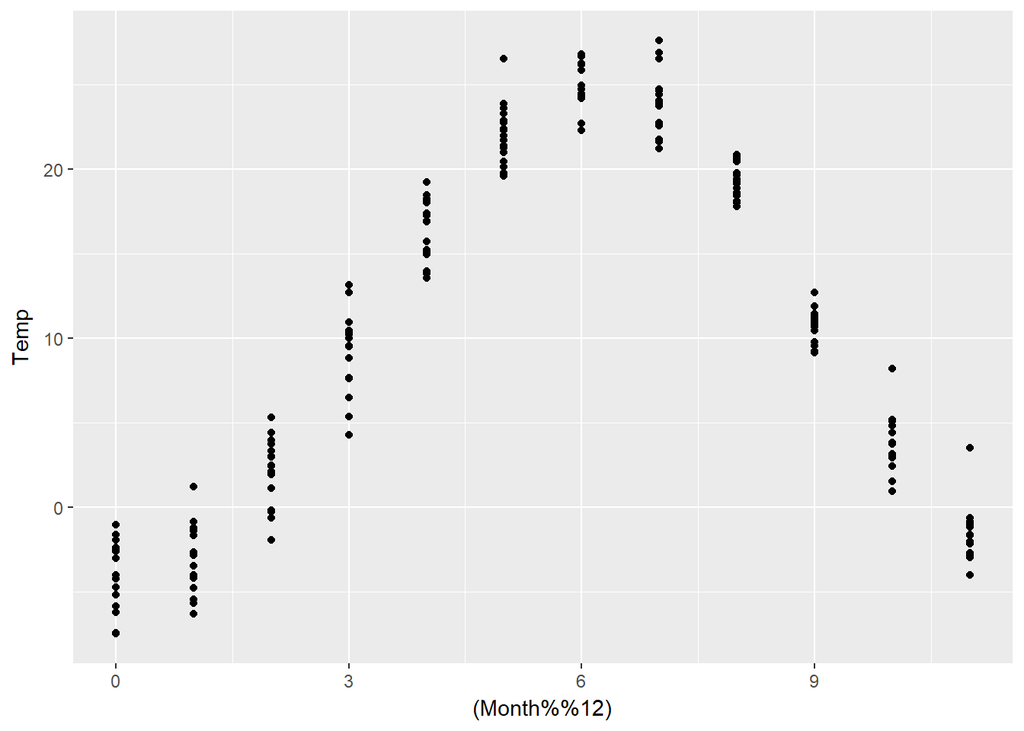

```r
ggplot(aes(x = (Month%%12), y = Temp), data = Mitchell) +
  geom_point()
```

### Understanding Noise: Age to Age Months

Notes:

```r
pf$age_with_months <- (pf$age) + (1 - (pf$dob_month/12))
head(pf)
```

```
##    userid age dob_day dob_year dob_month gender tenure friend_count
## 1 2094382  14      19     1999        11   male    266            0
## 2 1192601  14       2     1999        11 female      6            0
## 3 2083884  14      16     1999        11   male     13            0
## 4 1203168  14      25     1999        12 female     93            0
## 5 1733186  14       4     1999        12   male     82            0
## 6 1524765  14       1     1999        12   male     15            0
##   friendships_initiated likes likes_received mobile_likes
## 1                     0     0              0            0
## 2                     0     0              0            0
## 3                     0     0              0            0
## 4                     0     0              0            0
## 5                     0     0              0            0
## 6                     0     0              0            0
##   mobile_likes_received www_likes www_likes_received age_with_months
## 1                     0         0                  0        14.08333
## 2                     0         0                  0        14.08333
## 3                     0         0                  0        14.08333
## 4                     0         0                  0        14.00000
## 5                     0         0                  0        14.00000
## 6                     0         0                  0        14.00000
```

### Age with Months Means

```r
library(dplyr)

age_with_months <- group_by(pf, age_with_months)
pf.fc_by_age_months <- summarize(
  age_with_months,
  friend_count_mean = mean(friend_count),
  friend_count_median = median(friend_count),
  n = n()
)

pf.fc_by_age_months <- arrange(pf.fc_by_age_months, age_with_months)

head(pf.fc_by_age_months)
```

```
## # A tibble: 6 x 4
##   age_with_months friend_count_mean friend_count_median     n
##             <dbl>             <dbl>               <dbl> <int>
## 1            13.2              46.3                30.5     6
## 2            13.2             115.                 23.5    14
## 3            13.3             136.                 44.0    25
## 4            13.4             164.                 72.0    33
## 5            13.5             131.                 66.0    45
## 6            13.6             157.                 64.0    54
```

### Noise in Conditional Means

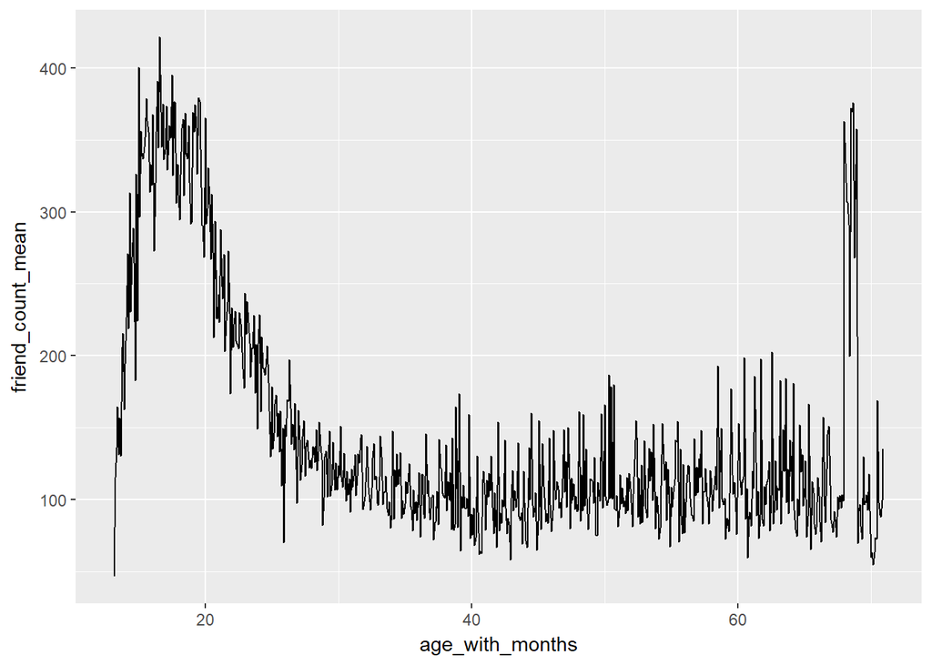

```r
ggplot(aes(x = age_with_months, y = friend_count_mean), data = subset(pf.fc_by_age_months, age_with_months<71)) +
  geom_line()
```

### Smoothing Conditional Means

Notes:

```r
library(gridExtra)
```

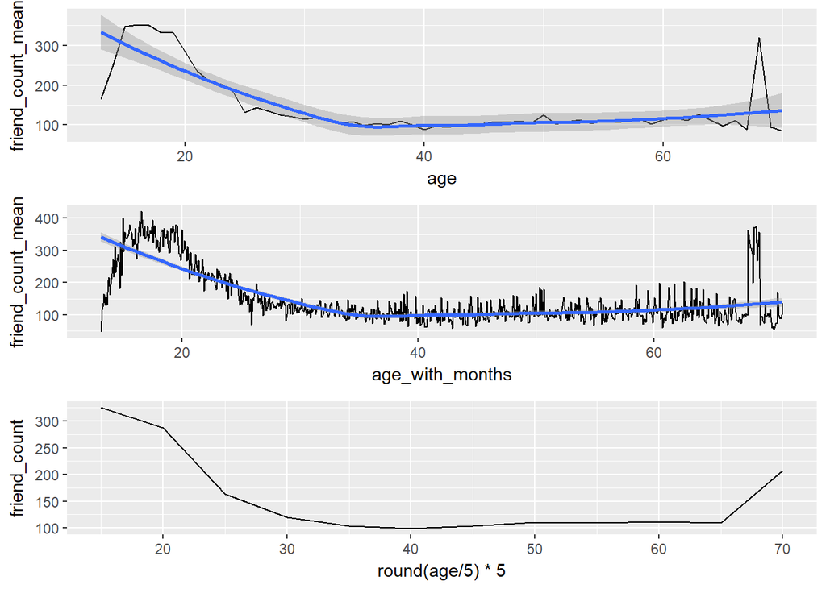

```r
p1 <- ggplot(aes(x = age, y = friend_count_mean), data = subset(pf.fc_by_age, age < 71)) +
  geom_line() +
  geom_smooth()
p2 <- ggplot(aes(x = age_with_months, y = friend_count_mean), data = subset(pf.fc_by_age_months, age_with_months < 71)) +
  geom_line() +
  geom_smooth()
p3 <- ggplot(aes(x = round(age / 5) * 5, y = friend_count), data = subset(pf, age < 71)) +
  geom_line(stat = 'summary', fun.y = 'mean')
grid.arrange(p1, p2, p3)
```

### Which Plot to Choose?

Notes:

Make multiple plots during the exploritory phase and then refine them down into the best plots for distribution.

### Analyzing Two Variables

Reflection:

Making multiple plots can show different features of the data. Also while summaries and correlations are good for a lot of things they are not always the best at portraying the data.

Click **KnitHTML** to see all of your hard work and to have an html page of this lesson, your answers, and your notes!